# Introduction to single-cell RNA-seq analysis - Data sets and analyses

Nov 2021

## Data sets

- Childhood acute lymphoblastic leukemia (cALL)
  - [Caron et al. 2020](https://www.nature.com/articles/s41598-020-64929-x)
  - the most common pediatric cancer
  - characterized by bone marrow lymphoid precursors
  - that acquire genetic alterations,
  - resulting in disrupted maturation and uncontrollable proliferation
  - up to 85–90% of patients are cured
  - others do not respond to treatment or relapse and die
  - **Aim**: characterise the heterogeneity of gene expression at the cell level, within and between patients
  - **cells**: Bone Marrow Mononuclear cells (BMMCs)
- Adult bone marrow
  - [‘HCA’: adult BMMCs](https://data.humancellatlas.org/explore/projects/cc95ff89-2e68-4a08-a234-480eca21ce79) (ABMMCs) obtained from the Human Cell Atlas (HCA)

## Samples

Four types of sample are considered:

- B-ALL patients:
  - four ‘t(12;21)’ or **‘ETV6-RUNX1’**
  - two ‘High hyper diploid’ or **‘HHD’**
- T-ALL patients
  - two **‘PRE-T’**
- three **healthy pediatric controls**
- eight **healthy adult controls**, publicly available

As the study aims at identifying cell populations, large numbers of cells were sequenced with the droplet-based 10x Chromium assay.

## Analyses

We will follow several steps:

- sequencing quality check
- alignment of reads to the human genome (GRCh38) with 10x software cellranger
- quality control (cell calls, cells and genes filtering)
- UMI count normalisation
- feature selection and dimensionality reduction
- data set integration (PBMMC and ETV6-RUNX1)
- clustering
- identification of cluster marker genes
- differential expression and abundance between conditions
- (trajectory analysis)

## Workflow

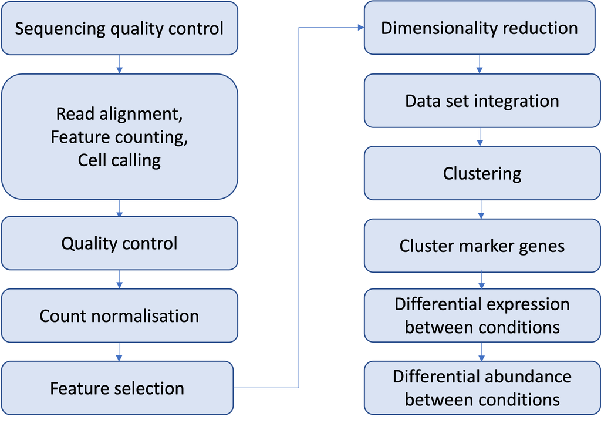